# PEA-F22-F-3577-DCA Restoring Fish Passage in the Peace Region

Prepared for Fish and Wildlife Compensation Program Fish Passage Technical Working Group Prepared by Al Irvine, B.Sc., R.P.Bio. New Graph Environment Ltd. Prepared with financial support of the Fish and Wildlife Compensation Program on behalf of its program partners BC Hydro, the Province of BC, Fisheries and Oceans Canada, First Nations and Public Stakeholders.

Version 0.0.1 2022-05-26

# Acknowledgement

Modern civilization has a long journey ahead to acknowledge and address the historic and ongoing impacts of colonialism that have resulted in harm to the cultures and livelihoods living interconnected with our ecosystems for many thousands of years.

Many thanks to the McLeod Lake members of council that took the time to meet and discuss big picture goals for this collaboration. Thank you to Nathan Prince for viewing sites in the field, liaising with numerous players and tying this work together with the numerous other initiatives the Nation is advising and steering.

# Introduction

This report is available as pdf and as an online [interactive report](https://newgraphenvironment.github.io/fish_passage_parsnip_2021_reporting/) at https://newgraphenvironment.github.io/fish_passage_parsnip_2021_reporting/. We recommend viewing online as the web-hosted version contains more features and is more easily navigable. Please reference the website for the latest version number and download the latest pdf from https://github.com/NewGraphEnvironment/fish_passage_parsnip_2021_reporting/raw/master/docs/parsnip2021.pdf

This project builds on Society for Ecosystem Restoration Northern BC (SERNbc) work in 2019 - 2020 which can be referenced [here](https://newgraphenvironment.github.io/Parsnip_Fish_Passage/) (Allan Irvine 2020). In 2019, following a literature review, analysis of fish habitat modelling data, the Provincial Stream Crossing Inventory System (PSCIS) and a community scoping exercise within the McLeod Lake Indian Band habitat confirmation assessments were conducted throughout the Parsnip River watershed. At 17 sites where habitat confirmation assessments were conducted, crossings were rated for fish passage remediation priority. During the habitat confirmations a total of approximately 15 km of stream was assessed with 10 crossings rated as high priorities for rehabilitation, three crossings rated as moderate priorities and four crossings rated as low priorities.

The health and viability of freshwater fish populations can depend on access to tributary and off channel areas which provide refuge during high flows, opportunities for foraging, overwintering habitat, spawning habitat and summer rearing habitat (Bramblett et al. 2002; Swales and Levings 1989; Diebel et al. 2015). Culverts can present barriers to fish migration due to low water depth, increased water velocity, turbulence, a vertical drop at the culvert outlet and/or maintenance issues (Slaney, Zaldokas, and Watershed Restoration Program (B.C.) 1997; Cote et al. 2005). As road crossing structures are commonly upgraded or removed there are numerous opportunities to restore connectivity by ensuring that fish passage considerations are incorporated into repair, replacement, relocation and deactivation designs.

# Goal and Objectives

The project engages FWCP partners and stakeholders to clearly communicate fish passage issues in the Parsnip River watershed while collaboratively planning and executing the steps necessary to realize fish passage restorations. Work completed and ongoing aligns with the Fish and Wildlife Compensation Program Rivers, Lakes and Reservoirs Action Plan (Fish and ildlife Compensation Program 2020) sub objective 6 of addressing fish passage issues in streams to enhance productivity of priority species. Project activities undertaken coincide with the following actions:

- PEA.RLR.S06.RI.20 - Conducting engagement to prioritize options for fish passage improvement-P1
- PEA.RLR.S06.RI.19 - Conducting research to prioritize fish passage actions-P1
- PEA.RLR.S06.HB.21 - Restoring fish access to streams-P1

# Study Area and Background

## Tse’khene

The Parsnip River watershed is located within the south-eastern portion of the 108,000 km<sup>2</sup> traditional territory of the Tse’khene from the [McLeod Lake Indian Band](https://www.mlib.ca/about/History). The Tse’khene *“People of the Rocks”* are a south westerly extension of the Athabascan speaking people of northern Canada. They were nomadic hunters whose language belongs to the Beaver-Sarcee-Tse’khene branch of Athapaskan (“History - Who We Are” n.d.). Extensive work is underway to preserve the language with resources such as First Voices available online and in [app form](https://apps.apple.com/us/app/tsekhene-mcleod-lake/id1503929250) for iphone and ipad devices (First People Cultural Council 2022; Language and Council 2022).

The continental divide separates watersheds flowing north into the Arctic Ocean via the Mackenzie River and south and west into the Pacific Ocean via the Fraser River (Figure 1). The Parsnip River is a 6th order stream with a watershed that drains an area of 5597km<sup>2</sup>. The mainstem of the river flows within the Rocky Mountain Trench in a north direction into Williston Reservoir starting from the continental divide adjacent to Arctic Lakes. Major tributaries include the Misinchinka, Colbourne, Reynolds, Anzac, Table, Hominka and Missinka sub-basins which drain the western slopes of the Hart Ranges of the Rocky Mountains. The Parsnip River has a mean annual discharge of 147.3 m<sup>3</sup>/s with flow patterns typical of high elevation watersheds on the west side of the northern Rocky Mountains which receive large amounts of precipitation as snow leading to peak levels of discharge during snowmelt, typically from May to July (Figures 2 - 3).

Construction of the 183 m high and 2134 m long W.A.C. Bennett Dam was completed in 1967 at Hudson’s Hope, BC, creating the Williston Reservoir (Hirst 1991). Filling of the 375km<sup>2</sup> reservoir was complete in 1972 and flooded a substantial portion of the Parsnip River and major tributary valleys forming what is now known as the Peace and Parsnip reaches. The replacement of riverine habitat with an inundated reservoir environment resulted in profound changes to the ecology, resource use and human settlement patterns in these systems (Hagen et al. 2015a; Pearce 2019; Stamford, Hagen, and Williamson 2017a). Prior to the filling of the reservoir, the Pack River, into which McLeod Lake flows, was a major tributary to the Parsnip River. The Pack River currently enters the Williston Reservoir directly as the historic location of the confluence of the two rivers lies within the reservoir’s footprint.

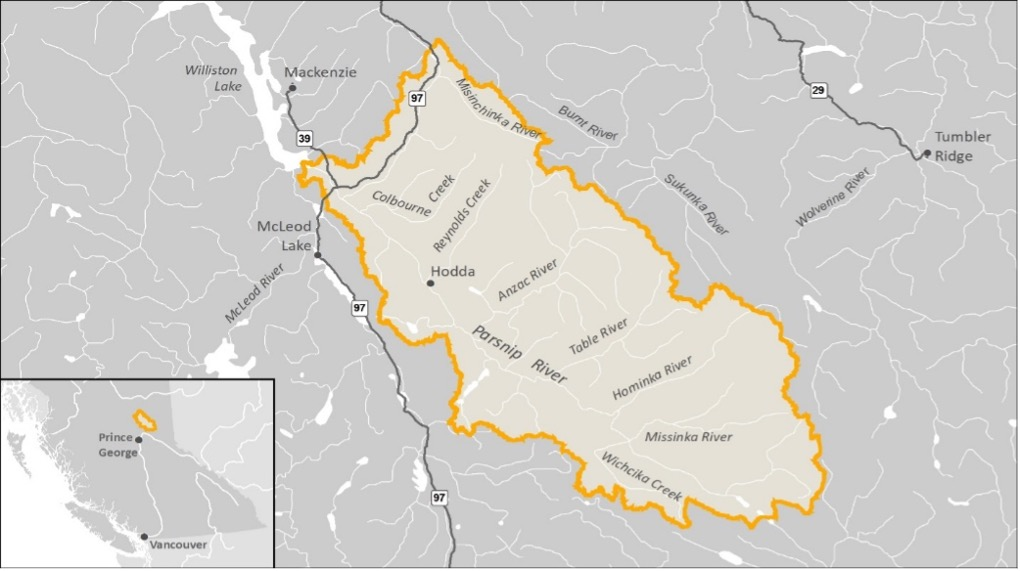

Figure 1: Overview map of study area

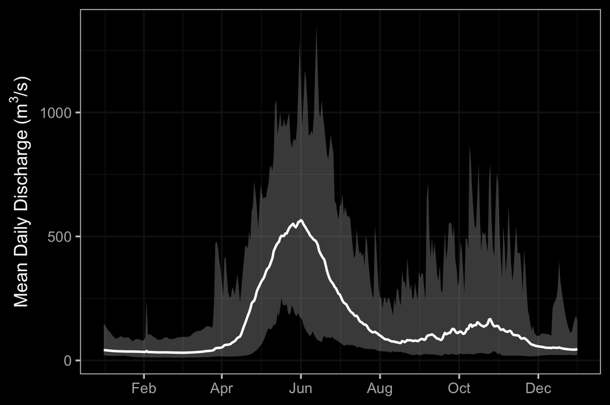

Figure 2: Parsnip River Above Misinchinka River (Station #07EE007 - Lat 55.08194 Lon -122.913063). Available daily discharge data from 1967 to 2019.

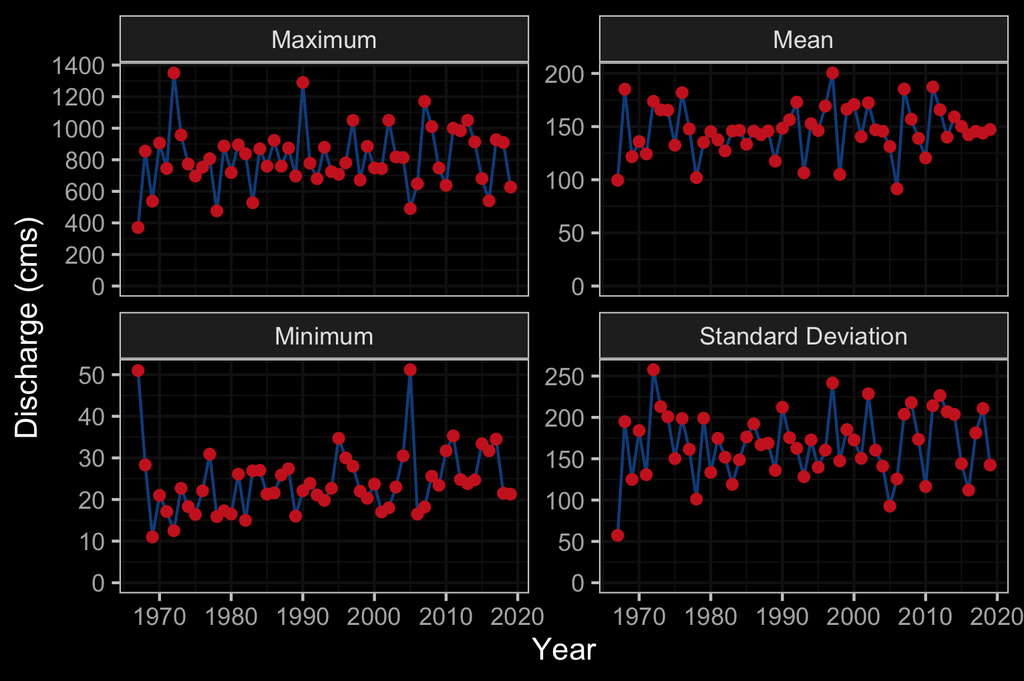

Figure 3: Summary discharge statistics (annual maximum, minimum, mean and standard deviation) for Parsnip River at hydrometric station #07EE007.

## Fisheries

Table 1: Fish species recorded in the Parsnip River watershed group.

| Scientific Name | Species Name | Species Code | BC List | Provincial FRPA | COSEWIC | SARA |
| --- | --- | --- | --- | --- | --- | --- |
| Catostomus catostomus | Longnose Sucker | LSU | Yellow | – | – | – |
| Catostomus commersonii | White Sucker | WSU | Yellow | – | – | – |
| Catostomus macrocheilus | Largescale Sucker | CSU | Yellow | – | – | – |
| Coregonus clupeaformis | Lake Whitefish | LW | Yellow | – | – | – |
| Cottus aleuticus | Coastrange Sculpin (formerly Aleutian Sculpin) | CAL | Yellow | – | – | – |
| Cottus asper | Prickly Sculpin | CAS | Yellow | – | – | – |
| Cottus cognatus | Slimy Sculpin | CCG | Yellow | – | – | – |
| Couesius plumbeus | Lake Chub | LKC | Yellow | – | DD | – |
| Lota lota | Burbot | BB | Yellow | – | – | – |
| Mylocheilus caurinus | Peamouth Chub | PCC | Yellow | – | – | – |
| Oncorhynchus mykiss | Rainbow Trout | RB | Yellow | – | – | – |
| Oncorhynchus nerka | Kokanee | KO | Yellow | – | – | – |
| Osmerus dentex | Rainbow Smelt | RSM | Unknown | – | – | – |
| Prosopium coulterii | Pygmy Whitefish | PW | Yellow | – | NAR (Nov 2016) | – |
| Prosopium cylindraceum | Round Whitefish | RW | Yellow | – | – | – |
| Prosopium williamsoni | Mountain Whitefish | MW | Yellow | – | – | – |
| Ptychocheilus oregonensis | Northern Pikeminnow | NSC | Yellow | – | – | – |
| Rhinichthys cataractae | Longnose Dace | LNC | Yellow | – | – | – |
| Richardsonius balteatus | Redside Shiner | RSC | Yellow | – | – | – |
| Salvelinus confluentus | Bull Trout | BT | Blue | Y (Jun 2006) | SC (Nov 2012) | – |
| Salvelinus fontinalis | Brook Trout | EB | Exotic | – | – | – |
| Salvelinus malma | Dolly Varden | DV | Yellow | – | – | – |
| Salvelinus namaycush | Lake Trout | LT | Yellow | – | – | – |
| Thymallus arcticus | Arctic Grayling | GR | Yellow | – | – | – |

### Bull Trout

Bull Trout populations of the Williston Reservoir watershed are included within the Western Arctic population ‘Designatable Unit 10’, which, in 2012, received a ranking of ‘Special Concern’ by the Committee on the Status of Endangered Wildlife in Canada (COSEWIC 2012). They were added to Schedule 1 under the Species of Risk Act in 2019 (Species Registry Canada 2020) and are also considered of special concern (blue-listed) provincially (BC Species & Ecosystem Explorer 2020). Some or all of the long-term foot survey index sections of four Williston Reservoir spawning tributaries (Davis Creek, Misinchinka River, Point Creek, and Scott Creek), have been surveyed within 16 of the 19 years between 2001 and 2019 (16 of 19 in Davis River, 10 years over a 13-year period in the Misinchinka River, 11 years over a 14-year period for Point Creek, and 9 years over an 11-year period for Scott Creek (Hagen, Spendlow, and Pillipow 2020).

A study of bull trout critical habitats in the Parsnip River was conducted in 2014 with the Misinchinka and Anzac systems identified as the most important systems for large bodied bull trout spawners accounting for a combined total of 65% of spawners counted. The Table River was also highlighted as an important spawning destination accounting for an estimated 15% of the spawners. Other watersheds identified as containing runs of large bodied bull troutspawners included the Colbourne, Reynolds, Hominka and Missinka River with potentially less than 50 spawners utilizing each sub-basin (Hagen et al. 2015a). Hagen and Weber (2019b) have synthesized a large body of information regarding limiting factors, enhancement potential, critical habitats and conservation status for bull trout of the Williston Reservoir and the reader is encouraged to review this work for context. They have recommended experimental enhancements within a monitoring framework for Williston Reservoir bull trout (some spawning and rearing in Parsnip River mainstem and tributaries) which include stream fertilization, side channel development, riparian restoration and fish access improvement.

In 2018, sub-basins of the Anzac River watershed, Homininka River, Missinka River and Table River watersheds were designated as fisheries sensitive watersheds under the authority of the *Forest and Range Practices Act* due to significant downstream fisheries values and significant watershed sensitivity (Beaudry 2013a, 2014a, 2014b, 2013b). Special management is required in these watersheds to protect habitat for fish species including bull trout and Arctic grayling including measures (among others) to limit equivalent clearcut area, reduce impacts to natural stream channel morphology, retain old growth attributes and maintain fish habitat/movement (Forest and Range Practices Act 2018).

Tse’khene Elders from the McLeod Lake Indian Band report that sa’ba (bull trout) size and abundance has decreased in all rivers and tributaries from the reservoir with more injured and diseased fish captured in recent history than was common in the past (Pearce 2019).

### Arctic Grayling

A detailed review of Arctic grayling life history can be referenced in Stamford, Hagen, and Williamson (2017b). Since impoundment of the Williston Reservoir, it appears that physical habitat and ecological changes have been the most significant factors limiting Arctic grayling productivity. Although these changes are not well understood they have likely resulted in the inundation of key low gradient juvenile rearing and overwintering habitats, isolation of previously connected populations and increases in abundance of predators such as bull trout (Shrimpton, Roberts, and Clarke 2012; Hagen, Pillipow, and Gantner 2018).

Migration of mature adult Arctic grayling occurs in the spring with arrival at known spawning locations coinciding with water temperatures of 4$^\circ$C. Spawning in the Parsnip watershed appears to occur between late-May and late-June within sites located primarily within the lower reaches of the Anzac and Table rivers as well as within the Parsnip River mainstem. Side-channel and multiple-channel locations containing small gravels appear to be selected for spawning. Currently, the primary distribution of Williston Arctic grayling appears to be among fourth order and larger streams (Williamson and Zimmerman 2005; Stamford, Hagen, and Williamson 2017b). Stewart et al. (2007) report that Arctic grayling spawn in large and small tributaries to rivers and lakes, intermittent streams, within mainstem rivers as well as lakes, most commonly at tributary mouths. Although past study results indicate that 0+ grayling appeared to overwinter in lower reaches of larger tributaries (i.e. Table, Anzac rivers) as well as the Parsnip River and that few age-1+ grayling have been sampled in tributaries, habitat use in small tributaries and the extent they are connected with the mainstem habitats of all core areas is not well understood. Between 1995 and 2019, Arctic grayling population monitoring has been conducted in the Table River in nine out of 25 years (8 years for the Anzac) using snorkel surveys. Results from 2018 are 2019 are intended to contribute to the assessment of the conservation status of the species in the Parsnip Core area (Hagen, Pillipow, and Gantner 2018).

Tse’khene Elders from the McLeod Lake Indian Band report that Arctic grayling numbers have declined dramatically since the flooding of the reservoir and that few dusk’ihje (Arctic Grayling) have been caught in the territory in the past 30 years (Pearce 2019).

# Methods

## Engagement

From May 2021 to the time of reporting SERNbc and McLeod Lake staff have been actively engaging with the following groups to discuss the project, solicit input, prioritize sites and plan fish passage remediation.

- McLeod Lake Indian Band members of council
- BCTS Engineering
- CN Rail
- Canadian Forest Products (Canfor)
- Sinclar Forest Projects Ltd. (Sinclar)
- Northern Engineering - Forests, Lands, Natural Resource Operations and Rural Development (FLNR)
- BC Ministry of Transportation and Infrastructure
- Fish Passage Technical Working Group
- Planning foresters and biologists Ministry of Forests, Lands, Natural Resource Operations and Rural Development (restructured into Ministry of Forests and Ministry of Land, Water and Resource Stewardship)
- Fisheries experts

### Environmental Stewardship Initiative

The [Environmental Stewardship Initiative](https://www2.gov.bc.ca/gov/content/environment/natural-resource-stewardship/consulting-with-first-nations/collaborative-stewardship-bc/environmental-stewardship-initiative)(ESI) is a collaborative partnership between the Province and First Nations with projects designed to focus on ecosystem assessment, restoration, enhancement, research and education . To date, four regional environmental stewardship projects have been developed. A governance working group with representatives from all four stewardship forums provides governance oversight and guidance for the ESI. The Parsnip River watershed group is within the Regional Strategic Environmental Assessment Forum (RSEA) area.

Working together with McLeod Lake Indian Band we are leveraging RSEA initiatives by overlaying Parsnip River watershed group fish passage planning data with the [Recreational Opportunity Spectrum Inventory data](https://catalogue.data.gov.bc.ca/dataset/recreational-opportunity-spectrum-inventory) to facilitate discussions with partners and stakeholders about how long term landscape stewardship goals of McLeod Lake Indian Band relate to stream crossing infrastructure upgrades/removals within their traditional territory. The inventory data summarizes recreation opportunities as combinations of settings and probable human experience opportunities organized along a spectrum of classes. The spectrum is set out in terms of seven classes as follows: Primitive (P), Semi-primitive Non-motorized (SPNM), Semi-primitive Motorized (SPM), Roaded Natural (RN), Roaded Modified (RM), Rural (R), Urban (U). The general idea is that areas towards the primitive end of the spectrum provide more opportunities for First Nations groups such as the McLeod Lake Indian Band to exercise their rights as indigenous people in pristine areas within their traditional territory (United Nations General Assembly 2007).

## Habitat Modelling

Through this initiative as well as other SERNbc led initiatives (A. Irvine 2021, [2021] 2022), as well as through direction from the Provincial Fish Passage Remediation Program and connectivity restoration planning conducted by Canadian Wildlife Federation and others (Mazany-Wright et al. 2021; A. Irvine 2022), `bcfishpass` has been designed to prioritize potential fish passage barriers for assessment or remediation. The software is under continual development and has been designed and constructed by Norris ([2020] 2021) using of sql and python based shell script libraries to generate a simple model of aquatic habitat connectivity. The model identifies natural barriers (ex. steep gradients for extended distances) and hydroelectric dams to classifying the accessibility upstream by fish (Norris [2020] 2021). On potentially accessible streams, scripts identify known barriers (ex. waterfalls >5m high) and additional anthropogenic features which are primarily road/railway stream crossings (i.e. culverts) that are potentially barriers. To prioritize these features for assessment or remediation, scripts report on how much modelled potentially accessible aquatic habitat the barriers may obstruct. The model can be refined with known fish observations upstream of identified barriers and for each crossing location, the area of lake and wetland habitat upstream, species documented upstream/downstream, an estimate of watershed area (on 2nd order and higher streams), mean annual precipitation weighted to upstream watershed area and channel width can be collated using `bcfishpass`, `fwapg` and `bcfishobs`. This, information, can be used to provide an indication of the potential quantity and quality of habitat potentially gained should fish passage be restored by comparing to user defined thresholds for the aforementioned parameters.

`bcfishpass` calculates the average gradient of BC Freshwater Atlas stream network lines at minimum 100m long intervals starting from the downstream end of the streamline segment and working upstream. The network lines are broken into max gradient categories with new segments created if and when the average slope of the stream line segment exceeds user provided thresholds. For this project, the user provided gradient thresholds used to delineate “potentially accessible habitat” were based on estimated max gradients that rainbow trout (20%) and bull trout (25%) are likely to be capable of ascending.

Gradient, channel size and stream discharge are key determinants of channel morphology and subsequently fish distribution. High value rearing, overwintering and spawning habitat preferred by numerous species/life stages of fish are often located within channel types that have relatively low gradients and large channel widths (also quantified by the amount of flow in the stream). Following delineation of “potentially accessible habitat”, the average gradient of each stream segment within habitat classified as below the 20% and 25% thresholds was calculated and summed within species and life stage specific gradient categories. Average gradient of stream line segments can be calculated from elevations contained in the provincial freshwater atlas streamline dataset. To obtain estimates of channel width upstream of crossing locations, where available, `bcfishpass` was utilized to pull average channel gradients from Fisheries Information Summary System (FISS) site assessment data (MoE 2019b) or PSCIS assessment data (MoE 2021) and associate with stream segment lines. When both FISS and PSCIS values were associated with a particular stream segment, FISS channel width was used. When multiple FISS sites were associated with a particular stream segment a mean of the average channel widths was taken. To model channel width for 2nd order and above stream segments without associated FISS or PSCIS sites, first `fwapg` was used to estimate the drainage area upstream of the segment. Then, rasters from ClimateBC (Wang et al. 2012) were sampled for upstream watershed areas associated with each stream segment and a mean annual precipitation weighted by upstream watershed area was calculated. In April of 2021, Bayesian statistical methods were used to model channel width in all provincial freshwater atlas stream segments where measurements had not previously been taken, based on the relationship between watershed area and mean annual precipitation weighted by upstream watershed area (Thorley and Irvine 2021).

## Online Mapping

# Results and Discussion

## Partnership Funding

SERN was able to aquire $105,000 of partnership funding from FLNR ($80,000) and the Provincial Fish Passage Technical Working Group ($25,000) towards the 2021/2022 program. Additionally, we have obtained a commitment for $25,000 of partnership funding from the the Provincial Fish Passage Technical Working Group towards the 2022/2023 program.

## Planned Remediations

### 0.0.1 PSCIS Crossing 125179 - Tributary to Missinka River

We are working together with McLeod Lake and Sinclar to advance crossing [125179 (Tributary to Missinka River)](https://newgraphenvironment.github.io/Parsnip_Fish_Passage/03_Parsnip_report_125179.html). Works to replace the crossing are planned for summer of 2022. A map of the watershed is provided in map attachment [093I.116](https://hillcrestgeo.ca/outgoing/fishpassage/projects/parsnip/FishPassage_093I.116.pdf).

Although this crossing is used to access an area of significant cultural value to McLeod Lake due to high recreational values [(unmotorized primitive)](https://catalogue.data.gov.bc.ca/dataset/recreational-opportunity-spectrum-inventory), and is located within a watershed where expansion of “unmotorized primitive” values will occur in the future through deactivation of roads and reforestation, this site was selected as appropriate for restoration for the following reasons:

[output not shown]

Leveraging support from FWCP, Sinclar will obtain portions of the remaining funding for this work planned for the summer of 2022 through the forestry appraisal system.

Table 2: Summary of fish habitat modelling for PSCIS crossing 125179.

| Habitat | Potential | Remediation Gain | Remediation Gain (%) |
| --- | --- | --- | --- |
| ST Network (km) | 0 | 0 | – |
| ST Lake Reservoir (ha) | 0 | 0 | – |
| ST Wetland (ha) | 0 | 0 | – |
| ST Slopeclass03 Waterbodies (km) | 0 | 0 | – |
| ST Slopeclass03 (km) | 0 | 0 | – |
| ST Slopeclass05 (km) | 0 | 0 | – |
| ST Slopeclass08 (km) | 0 | 0 | – |
| ST Spawning (km) | 0 | 0 | – |
| ST Rearing (km) | 0 | 0 | – |
| CH Spawning (km) | 0 | 0 | – |
| CH Rearing (km) | 0 | 0 | – |
| CO Spawning (km) | 0 | 0 | – |
| CO Rearing (km) | 0 | 0 | – |
| CO Rearing (ha) | 0 | 0 | – |
| SK Spawning (km) | 0 | 0 | – |
| SK Rearing (km) | 0 | 0 | – |
| SK Rearing (ha) | 0 | 0 | – |
| All Spawning (km) | 0 | 0 | – |
| All Rearing (km) | 0 | 0 | – |
| All Spawning Rearing (km) | 0 | 0 | – |

* Model data is preliminary and subject to adjustments.

### PSCIS 125000 - Tributary to Parsnip River

We are working together with McLeod Lake and Sinclar to advance the replacement of crossing [125000 (Tributary to Parsnip River)](https://newgraphenvironment.github.io/Parsnip_Fish_Passage/03_Parsnip_report_125000.html) on the Chuchinka-Arctic FSR. A map of the watershed is provided in map attachment [093I.111](https://hillcrestgeo.ca/outgoing/fishpassage/projects/parsnip/FishPassage_093I.111.pdf). The crossing was prioritized for restoration for the following reasons:

[output not shown]

Table 3: Summary of fish habitat modelling for PSCIS crossing 125000.

| Habitat | Potential | Remediation Gain | Remediation Gain (%) |
| --- | --- | --- | --- |
| ST Network (km) | 0 | 0 | – |
| ST Lake Reservoir (ha) | 0 | 0 | – |
| ST Wetland (ha) | 0 | 0 | – |
| ST Slopeclass03 Waterbodies (km) | 0 | 0 | – |
| ST Slopeclass03 (km) | 0 | 0 | – |
| ST Slopeclass05 (km) | 0 | 0 | – |
| ST Slopeclass08 (km) | 0 | 0 | – |
| ST Spawning (km) | 0 | 0 | – |
| ST Rearing (km) | 0 | 0 | – |
| CH Spawning (km) | 0 | 0 | – |
| CH Rearing (km) | 0 | 0 | – |
| CO Spawning (km) | 0 | 0 | – |
| CO Rearing (km) | 0 | 0 | – |
| CO Rearing (ha) | 0 | 0 | – |
| SK Spawning (km) | 0 | 0 | – |
| SK Rearing (km) | 0 | 0 | – |
| SK Rearing (ha) | 0 | 0 | – |
| All Spawning (km) | 0 | 0 | – |
| All Rearing (km) | 0 | 0 | – |
| All Spawning Rearing (km) | 0 | 0 | – |

* Model data is preliminary and subject to adjustments.

### PSCIS 125231 - Tributary to Table River

We are working together with McLeod Lake and Canfor to advance crossing [125231 (Tributary to Table River)](https://newgraphenvironment.github.io/Parsnip_Fish_Passage/03_Parsnip_report_125231.html) on the Chuchinka-Table FSR for the following reasons:

[output not shown]

Table 4: Summary of fish habitat modelling for PSCIS crossing 125231.

| Habitat | Potential | Remediation Gain | Remediation Gain (%) |
| --- | --- | --- | --- |
| ST Network (km) | 0 | 0 | – |
| ST Lake Reservoir (ha) | 0 | 0 | – |
| ST Wetland (ha) | 0 | 0 | – |
| ST Slopeclass03 Waterbodies (km) | 0 | 0 | – |
| ST Slopeclass03 (km) | 0 | 0 | – |
| ST Slopeclass05 (km) | 0 | 0 | – |
| ST Slopeclass08 (km) | 0 | 0 | – |
| ST Spawning (km) | 0 | 0 | – |
| ST Rearing (km) | 0 | 0 | – |
| CH Spawning (km) | 0 | 0 | – |
| CH Rearing (km) | 0 | 0 | – |
| CO Spawning (km) | 0 | 0 | – |
| CO Rearing (km) | 0 | 0 | – |
| CO Rearing (ha) | 0 | 0 | – |
| SK Spawning (km) | 0 | 0 | – |
| SK Rearing (km) | 0 | 0 | – |
| SK Rearing (ha) | 0 | 0 | – |
| All Spawning (km) | 0 | 0 | – |
| All Rearing (km) | 0 | 0 | – |
| All Spawning Rearing (km) | 0 | 0 | – |

* Model data is preliminary and subject to adjustments.

### 0.0.2 PSCIS 125345 - Tributary to Parsnip River

BCTS is planning to deactivate the Chuchinka-Colbourne FSR between where [125345 (Tributary to Parsnip River)](https://newgraphenvironment.github.io/Parsnip_Fish_Passage/03_Parsnip_report_125345.html) is located and the Chuckhinka-Anzac FSR to the south. The work is schedule for July and August of 2022. BCTS was able to engage the Forest Carbon Initiative about the project, who has confirmed that they have funding available for a full road rehabilitation on this section and are able to fund the replanting and road decompaction. This full scale rehabilitation will provide more intensity towards re-vegetation and access management than traditional deactivation practices. We have been in contact with CN Rail to advocate for the removal of crossing 57687 located under the railway immediately upstream of the PSCIS crossing 125345 and the FSR. Discussions are ongoing and we are hopeful action will be taken by CN this summer to remediate crossing 57687 as well.

Table 5: Summary of fish habitat modelling for PSCIS crossing 125345.

| Habitat | Potential | Remediation Gain | Remediation Gain (%) |
| --- | --- | --- | --- |
| ST Network (km) | 0.0 | 0 | – |
| ST Lake Reservoir (ha) | – | 0 | – |
| ST Wetland (ha) | – | 0 | – |
| ST Slopeclass03 Waterbodies (km) | 0.0 | 0 | – |
| ST Slopeclass03 (km) | 0.0 | 0 | – |
| ST Slopeclass05 (km) | 0.0 | 0 | – |
| ST Slopeclass08 (km) | 0.0 | 0 | – |
| ST Spawning (km) | 0.0 | 0 | – |
| ST Rearing (km) | 0.0 | 0 | – |
| CH Spawning (km) | 0.0 | 0 | – |
| CH Rearing (km) | 0.0 | 0 | – |
| CO Spawning (km) | 0.0 | 0 | – |
| CO Rearing (km) | 0.0 | 0 | – |
| CO Rearing (ha) | – | 0 | – |
| SK Spawning (km) | 0.0 | 0 | – |
| SK Rearing (km) | 0.0 | 0 | – |
| SK Rearing (ha) | – | 0 | – |
| All Spawning (km) | 5.0 | 0 | 0 |
| All Rearing (km) | 13.3 | 0 | 0 |
| All Spawning Rearing (km) | 13.3 | 0 | 0 |

* Model data is preliminary and subject to adjustments.

## Habitat Modelling

In December of 2021, Bayesian statistical methods were used to update our model of stream channel width based on a power model derived by Finnegan et al. (2005) which relates stream discharge to watershed area and mean annual precipitation. Data (n = 24849) on watershed size, mean annual precipitation and measured channel width was extracted from the provincial freshwater atlas (FLNRORD 2021; GeoBC 2022), the BC Data Catalouge fisheries datasets (MoE 2020, 2021) and Wang et al. (2012) utilizing `bcfishpass` (Norris [2020] 2021) and `fwapg` (Norris [2019] 2021). This data used to model channel width using Bayesian statistical methods analyzing the relationship between the input variables. The details of this analysis and resulting formula are documented in Thorley, Norris, and Irvine (2021) and were used to estimate channel width of stream segments in the Parsnip River watershed to facilitate modelling of highest intrinsic fisheries habitat value. The analysis is attached as a technical appendix at https://www.poissonconsulting.ca/f/859859031.

We are leveraging this project together with numerous others to contributing to the open source development of [`bcfishpass`](https://github.com/smnorris/bcfishpass) and [`fwapg`](https://github.com/smnorris/fwapg) and using these database building and habitat/connectivity modeling tools to conduct reproducible analysis/presentation of fish passage restoration opportunities in the Parsnip River watershed in order to facilitate outreach, prioritize sites and provide the background information necessary to communicate restoration plans/actions effectively.

Working with Ministry of Environment and Climate Change Strategy we have accessed historic electrofishing data for the entire province from British Columbia databases to begin developing evidence based approaches to modelling the highest value habitat for individual fish species. This work is an important step to increasing our state of knowledge, informing our field data collection and data management protocols provincially as well as for informing fish passage restoration investment decisions and monitoring outcomes. This work leverages many initiatives throughout the province and is briefly detailed [here](https://www.newgraphenvironment.com/fissr_explore/big-picture.html) with preliminary results presented as a digital attachment [here](https://www.poissonconsulting.ca/temporary-hidden-link/1386346791/fissr-explore-21/) (Amies-Galonski et al. 2022).

## Fisheries

Although it should not be assumed that all habitat types have been historically sampled equally, a review of available fisheries data for the Parsnip River watershed stratified by different habitat characteristics can provide insight into which habitats may provide the highest intrinsic value for fish species based on the number of fish captured in those habitats in past assessment work. Figures 4 - 6.

Table 6: Summary of historic salmonid observations vs. stream gradient category for the Parsnip River watershed group.

| species_code | Gradient | Count | total_spp | Percent |
| --- | --- | --- | --- | --- |
| BT | 0 - 3 % | 160 | 236 | 68 |
| BT | 03 - 5 % | 29 | 236 | 12 |
| BT | 05 - 8 % | 21 | 236 | 9 |
| BT | 08 - 15 % | 20 | 236 | 8 |
| BT | 15 - 22 % | 6 | 236 | 3 |
| GR | 0 - 3 % | 224 | 230 | 97 |
| GR | 03 - 5 % | 2 | 230 | 1 |
| GR | 05 - 8 % | 2 | 230 | 1 |
| GR | 08 - 15 % | 2 | 230 | 1 |
| KO | 0 - 3 % | 17 | 17 | 100 |
| RB | 0 - 3 % | 327 | 415 | 79 |
| RB | 03 - 5 % | 32 | 415 | 8 |
| RB | 05 - 8 % | 22 | 415 | 5 |
| RB | 08 - 15 % | 27 | 415 | 7 |
| RB | 15 - 22 % | 7 | 415 | 2 |

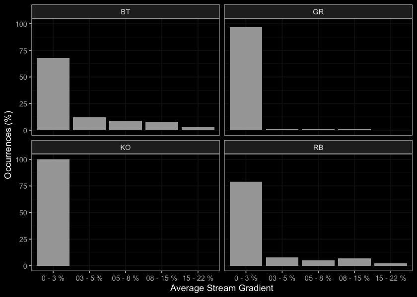

Figure 4: Summary of historic salmonid observations vs. stream gradient category for the Parsnip River watershed group.

Table 7: Summary of historic salmonid observations vs. channel width category for the Parsnip River watershed group.

| species_code | Width | Count | total_spp | Percent |
| --- | --- | --- | --- | --- |
| BT | 0 - 2m | 11 | 236 | 5 |
| BT | 02 - 04m | 25 | 236 | 11 |
| BT | 04 - 06m | 29 | 236 | 12 |
| BT | 06 - 10m | 35 | 236 | 15 |
| BT | 10 - 15m | 30 | 236 | 13 |
| BT | 15m+ | 103 | 236 | 44 |
| BT | – | 3 | 236 | 1 |
| GR | 04 - 06m | 5 | 230 | 2 |
| GR | 06 - 10m | 7 | 230 | 3 |
| GR | 10 - 15m | 14 | 230 | 6 |
| GR | 15m+ | 200 | 230 | 87 |
| GR | – | 4 | 230 | 2 |
| KO | 0 - 2m | 1 | 17 | 6 |
| KO | 06 - 10m | 3 | 17 | 18 |
| KO | 15m+ | 1 | 17 | 6 |
| KO | – | 12 | 17 | 71 |
| RB | 0 - 2m | 23 | 415 | 6 |
| RB | 02 - 04m | 51 | 415 | 12 |
| RB | 04 - 06m | 37 | 415 | 9 |
| RB | 06 - 10m | 36 | 415 | 9 |
| RB | 10 - 15m | 34 | 415 | 8 |
| RB | 15m+ | 141 | 415 | 34 |
| RB | – | 93 | 415 | 22 |

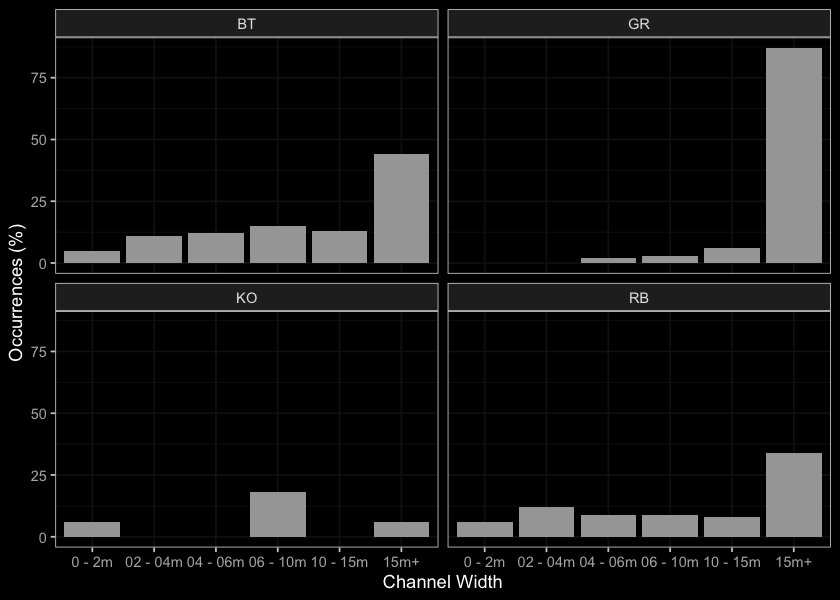

Figure 5: Summary of historic salmonid observations vs. channel width category for the Parsnip River watershed group.

Table 8: Summary of historic salmonid observations vs. watershed size category for the Parsnip River watershed group.

| species_code | Watershed | upstream_area_ha | Count | total_spp | Percent |
| --- | --- | --- | --- | --- | --- |
| BT | 0 - 2500ha | 16 | 2 | 236 | 1 |
| BT | 0 - 2500ha | 75 | 1 | 236 | 0 |
| BT | 0 - 2500ha | 76 | 1 | 236 | 0 |
| BT | 0 - 2500ha | 85 | 1 | 236 | 0 |
| BT | 0 - 2500ha | 90 | 1 | 236 | 0 |
| BT | 0 - 2500ha | 93 | 3 | 236 | 1 |
| BT | 0 - 2500ha | 96 | 1 | 236 | 0 |
| BT | 0 - 2500ha | 100 | 1 | 236 | 0 |
| BT | 0 - 2500ha | 112 | 1 | 236 | 0 |
| BT | 0 - 2500ha | 128 | 1 | 236 | 0 |
| BT | 0 - 2500ha | 133 | 1 | 236 | 0 |
| BT | 0 - 2500ha | 155 | 1 | 236 | 0 |
| BT | 0 - 2500ha | 168 | 1 | 236 | 0 |
| BT | 0 - 2500ha | 175 | 1 | 236 | 0 |
| BT | 0 - 2500ha | 192 | 1 | 236 | 0 |
| BT | 0 - 2500ha | 214 | 2 | 236 | 1 |
| BT | 0 - 2500ha | 226 | 1 | 236 | 0 |
| BT | 0 - 2500ha | 294 | 1 | 236 | 0 |
| BT | 0 - 2500ha | 297 | 1 | 236 | 0 |
| BT | 0 - 2500ha | 324 | 1 | 236 | 0 |
| BT | 0 - 2500ha | 330 | 1 | 236 | 0 |
| BT | 0 - 2500ha | 347 | 1 | 236 | 0 |
| BT | 0 - 2500ha | 356 | 1 | 236 | 0 |
| BT | 0 - 2500ha | 374 | 2 | 236 | 1 |
| BT | 0 - 2500ha | 404 | 1 | 236 | 0 |
| BT | 0 - 2500ha | 422 | 1 | 236 | 0 |
| BT | 0 - 2500ha | 430 | 1 | 236 | 0 |
| BT | 0 - 2500ha | 456 | 1 | 236 | 0 |
| BT | 0 - 2500ha | 460 | 2 | 236 | 1 |
| BT | 0 - 2500ha | 468 | 1 | 236 | 0 |

[output cut: 565 more lines]

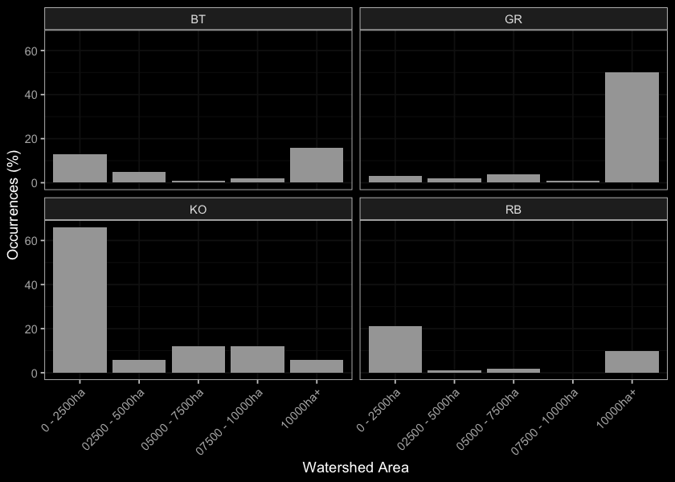

Figure 6: Summary of historic salmonid observations vs. watershed size category for the Parsnip River watershed group.

# Recomendations

A multi-year plan with one to two structure replacements (or removals) each year with works at each site phased over two years each is recommended. This approach will facilitate progress at a minimum of one site per year and allows ample time for planning, coordination and funding acquisition related to each restoration. Multi-year planning allows an inclusive environment to solicit funding collaboration with the numerous potential partners and stakeholders in the watershed (i.e. Sinclar, Canfor, CN Rail, Coastal Gas Link, FLNR, fish passage technical working group, Ministry of Transportation and Infrastructure, McLeod Lake, Treaty 8 Nations, etc.).

- In 2023/2024 we propose replacement of crossings where preparations were made in 2022/2023 in partnership with Sinclar. Sinclar has committed to obtaining portions of the funding for this work through the forestry appraisal system and we will actively engage with partners and stakeholders to obtain other funding contributions. Additionally, we propose preparations for structure replacement at an addition two sites that can be completed in the following fiscal. This model of progress is proposed to continue through 2025/2026 fiscal.
- In 2022/2023 we will work together with BCTS and other interested parties to rehabilitate and monitor the Chuchinka-Colbourne FSR where 125345 (Tributary to Parsnip River) will be removed and the road deactivated/decompacted and planted in 2022. We will continue to engage with CN to advance remediation of passage at crossing 57687 located under the railway immediately upstream of this site.
- We recommend continuing to engage FWCP partners and stakeholders to explore and clearly communicate fish passage issues in the Parsnip River watershed, build relationships and obtain partnership funding commitments while collaboratively prioritizing, planning and delivering fish passage restorations.
- We recommend continuing to implement capacity building programs that will provide resources and skills for watershed stakeholders and partners to engage in watershed restoration planning activities and on the ground works as well as to monitor outcomes of project initiatives.

# References

Amies-Galonski, E, J Thorley, A Irvine, and S Norris. 2022. “FISS Fish Density Exploratory Analysis 2021.” Poisson Consulting. 2022. https://poissonconsulting.ca/temporary-hidden-link/1386346791/fissr-explore-21/.

BC Species & Ecosystem Explorer. 2020. “Salvelinus Confluentus Pop. 10 (Bull Trout - Western Arctic Populations).” 2020. http://a100.gov.bc.ca/pub/eswp/reports.do?elcode=AFCHA05122.

Beaudry, Pierre G. 2013a. “Assessment and Assignment of Sensitivity Ratings to Sub-Basins of the Anzac Watershed in Parsnip Drainage – Ominieca Region. Contract Number: Gs14823018.” Report. http://a100.gov.bc.ca/pub/acat/public/viewReport.do?reportId=51630.

———. 2013b. “Assessment and Assignment of Sensitivity Ratings to Sub-Basins of the Missinka Watershed in Parsnp Drainage – Ominieca Region. Contract Number: Gs14fwh-006.” Report. P. Beaudry; Associates Ltd. http://a100.gov.bc.ca/pub/acat/public/viewReport.do?reportId=51631.

———. 2014a. “Assessment and Assignment of Sensitivity Ratings to Sub-Basins of the Hominka Watershed in Parsnip Drainage – Ominieca Region. Contract Number: Gs15823011.” Report. http://a100.gov.bc.ca/pub/acat/public/viewReport.do?reportId=51633.

———. 2014b. “Assessment and Assignment of Sensitivity Ratings to Sub-Basins of the Table Watershed in Parsnip Drainage – Ominieca Region. Contract Number: Gs15823011.” Report. http://a100.gov.bc.ca/pub/acat/public/viewReport.do?reportId=51634.

Bramblett, Robert, Mason Bryant, Brenda Wright, and Robert White. 2002. “Seasonal Use of Small Tributary and Main-Stem Habitats by Juvenile Steelhead, Coho Salmon, and Dolly Varden in a Southeastern Alaska Drainage Basin.” *Transactions of the American Fisheries Society* 131: 498–506. https://doi.org/10.1577/1548-8659(2002)131<0498:SUOSTA>2.0.CO;2.

Comittee on the Status of Endangered Wildlife in Canada. 2012. “COSEWIC Assessment and Status Report on the Bull Trout Salvelinus Confluentus.” Report. https://www.sararegistry.gc.ca/virtual_sara/files/cosewic/sr_omble_tete_plat_bull_trout_1113_e.pdf.

COSEWIC. 2012. “COSEWIC Assessment and Status Report on the Bull Trout Salvelinus Confluentus in Canada.” Report. Committee on the Status of Endangered Wildlife in Canada. https://www.sararegistry.gc.ca/virtual_sara/files/cosewic/sr_omble_tete_plat_bull_trout_1113_e.pdf.

Cote, David, P Frampton, M Langdon, and R Collier. 2005. *Fish Passage and Stream Habitat Restoration in Terra Nova National Park Highway Culverts*.

Diebel, M. W., M. Fedora, S. Cogswell, and J. R. O’Hanley. 2015. “Effects of Road Crossings on Habitat Connectivity for Stream-Resident Fish: STREAM-RESIDENT FISH HABITAT CONNECTIVITY.” *River Research and Applications* 31 (10): 1251–61. https://doi.org/10.1002/rra.2822.

Finnegan, Noah J., Gerard Roe, David R. Montgomery, and Bernard Hallet. 2005. “Controls on the Channel Width of Rivers: Implications for Modeling Fluvial Incision of Bedrock.” *Geology* 33 (3): 229–32. https://doi.org/10.1130/G21171.1.

First People Cultural Council. 2022. “Learn Tse’Khene (McLeod Lake).” 2022. https://www.firstvoices.com/explore/FV/sections/Data/Athabascan/Tse'Khene%20(McLeod%20Lake)/Tse'Khene%20(McLeod%20Lake)/learn.

Fish, and ildlife Compensation Program. 2020. “Peace Region Rivers, Lakes, & Reservoirs Action Plan.” https://fwcp.ca/app/uploads/2020/08/Action-Plan-Peace-Region-Rivers-Lakes-Reservoirs-Aug-11-2020.pdf.

FLNRORD. 2021. “Freshwater Atlas Stream Network - Data Catalogue.” Published by Ministry of Forests, Lands, Natural Resource Operations and Rural Development. 2021. https://catalogue.data.gov.bc.ca/dataset/freshwater-atlas-stream-network.

Forest and Range Practices Act. 2018. “Order - Fisheries Sensitive Watershed Prince George Forest District.” http://www.env.gov.bc.ca/wld/frpa/fsw/approved.html.

GeoBC. 2022. “Freshwater Atlas Watersheds - Datasets - Data Catalogue.” 2022. https://catalogue.data.gov.bc.ca/dataset/freshwater-atlas-watersheds.

Hagen, John, Ray Pillipow, and Nikolaus Gantner. 2018. “Trend in Abundance of Arctic Grayling (Thymallus Arcticus) in Index Sites of the Parsnip River Watershed, 1995-2018.” 37.

Hagen, John, Ian Spendlow, and Ray Pillipow. 2020. “Critical Spawning Habitats and Abundance of Bull Trout in the Williston Reservoir Watershed, 2019,” 57.

Hagen, John, and Susanne Weber. 2019a. “Limiting Factors, Enhancement Potential, Critical Habitats, and Conservation Status for Bull Trout of the Williston Reservoir Watershed: Information Synthesis and Recommended Monitoring Framework.” Report. http://fwcp.ca/app/uploads/2019/08/Bull-Trout-Info-Synthesis-Monitoring-Framework-_FINAL29Aug2019.pdf.

———. 2019b. “Limiting Factors, Enhancement Potential, Critical Habitats, and Conservation Status for Bull Trout of the Williston Reservoir Watershed: Information Synthesis and Recommended Monitoring Framework.” Report. http://fwcp.ca/app/uploads/2019/08/Bull-Trout-Info-Synthesis-Monitoring-Framework-_FINAL29Aug2019.pdf.

Hagen, John, Susanne Williamson, Mike Stamford, and Ray Pillipow. 2015b. “Critical Habitats for Bull Trout and Arctic Grayling Within the Parsnip River and Pack River Watersheds.”

———. 2015a. “Critical Habitats for Bull Trout and Arctic Grayling Within the Parsnip River and Pack River Watersheds.”

Hirst, S. M. 1991. “Impacts of the Operations of Existing Hydroelectric Developments on Fishery Resources in British Columbia.” https://waves-vagues.dfo-mpo.gc.ca/Library/124832main.pdf.

“History - Who We Are.” n.d. McLeod Lake Indian Band. Accessed May 26, 2020. https://www.mlib.ca/about/History.

Irvine, A. 2021. “Bulkley River and Morice River Watershed Groups Fish Passage Restoration Planning.” https://newgraphenvironment.github.io/fish_passage_bulkley_2020_reporting/.

———. (2021) 2022. “Bulkley River and Morice River Watershed Groups Fish Passage Restoration Planning 2021.” https://github.com/NewGraphEnvironment/fish_passage_skeena_2021_reporting.

———. 2022. “Elk River Watershed Group Fish Passage Restoration Planning 2021.” https://newgraphenvironment.github.io/fish_passage_elk_2021_reporting/.

Irvine, Allan. 2020. “Parsnip River Watershed – Fish Habitat Confirmations (PEA-F20-F-2967),” 139. https://newgraphenvironment.github.io/Parsnip_Fish_Passage/.

Language, First Peoples Heritage, and Culture Council. 2022. “Tse’Khene (McLeod Lake) on the App Store.” 2022. https://apps.apple.com/us/app/tsekhene-mcleod-lake/id1503929250.

Mazany-Wright, Nick, Simon M Norris, Joshua Noseworthy, Betty Rebellato, Sarah Sra, and Nicolas W R Lapointe. 2021. “Bulkley River Watershed (Laxyip | Wedzin Kwah),” 46. https://cwf-fcf.org/en/resources/research-papers/Bulkley_WCRP_10-08-2021.pdf.

MoE. 2019a. “Known BC Fish Observations and BC Fish Distributions.” Ministry of Environment and Climate Change Strategy - Knowledge Management. https://catalogue.data.gov.bc.ca/dataset/known-bc-fish-observations-and-bc-fish-distributions.

———. 2019b. “Stream Inventory Sample Sites.” Ministry of Environment and Climate Change Strategy - Knowledge Management. https://catalogue.data.gov.bc.ca/dataset/stream-inventory-sample-sites.

———. 2020. “Stream Inventory Sample Sites.” Ministry of Environment and Climate Change Strategy - Knowledge Management. 2020. https://catalogue.data.gov.bc.ca/dataset/stream-inventory-sample-sites.

———. 2021. “PSCIS Assessments - Data Catalogue.” Ministry of Environment and Climate Change Strategy - Knowledge Management (MoE). 2021. https://catalogue.data.gov.bc.ca/dataset/pscis-assessments.

Norris, Simon. (2019) 2021. *Smnorris/Fwapg*. https://github.com/smnorris/fwapg.

———. (2020) 2021. *Smnorris/Bcfishpass*. https://github.com/smnorris/bcfishpass.

Pearce, Dr Tristan. 2019. “First Nations Information Gathering on Kokanee, Bull Trout and Arctic Grayling: TSE’KHENE FIRST NATIONS - McLEOD LAKE INDIAN BAND.” https://a100.gov.bc.ca/pub/acat/documents/r57248/PEA-F19-F-2866-DCA-5-Final_Report-Arctic_North-Ko_1600902816644_0895426641.pdf.

Shrimpton, J. M., S. L. Roberts, and A. D. Clarke. 2012. “Genetic Analysis of Arctic Grayling Population Structure in the Williston Watershedcfe3011493.pdf.” http://a100.gov.bc.ca/appsdata/acat/documents/r38246/Report_311_GR_genetics_2012_1379090176074_c3e946726980918f9466d47b59978ad28ded2b969041dd7fe53b83cfe3011493.pdf.

Slaney, P. A, Daiva O Zaldokas, and Watershed Restoration Program (B.C.). 1997. *Fish Habitat Rehabilitation Procedures*. Vancouver, B.C.: Watershed Restoration Program. https://www.for.gov.bc.ca/hfd/library/FFIP/Slaney_PA1997_A.pdf.

Species Registry Canada. 2020. “Bull Trout (Salvelinus Confluentus), Western Arctic Populations - Species Search - Species at Risk Registry.” 2020. https://species-registry.canada.ca/index-en.html#/species/1202-869.

Stamford, Mike, John Hagen, and Susanne Williamson. 2017b. “FWCP Arctic Grayling Synthesis Report,” 148.

———. 2017a. “FWCP Arctic Grayling Synthesis Report,” 148. http://fwcp.ca/app/uploads/2017/07/FWCP_Grayling_Synthesis_Final.pdf.

Stewart, D B, N J Mochnacz, J D Reist, T J Carmichael, and C D Sawatzky. 2007. “Fish Life History and Habitat Use in the Northwest Territories: Arctic Grayling (Thymallus Arcticus).” *Canadian Manuscript Report of Fisheries and Aquatic Sciences 2797*, 64.

Swales, Stephen, and C. Levings. 1989. “Role of Off-Channel Ponds in the Life Cycle of Coho Salmon ( Oncorhynchus Kisutch ) and Other Juvenile Salmonids in the Coldwater River, British Columbia.” *Canadian Journal of Fisheries and Aquatic Sciences - CAN J FISHERIES AQUAT SCI* 46: 232–42. https://doi.org/10.1139/f89-032.

Thorley, J, and A Irvine. 2021. “Channel Width 2021.” Poisson Consulting. 2021. https://poissonconsulting.ca/temporary-hidden-link/1792764180/channel-width-21/.

Thorley, J, S Norris, and I Irvine. 2021. “Channel Width 2021b.” Poisson Consulting. 2021. https://poissonconsulting.ca/temporary-hidden-link/859859031/channel-width-21b/.

United Nations General Assembly. 2007. “United Nations Declaration on the Rights of Indigenous Peoples : Resolution / Adopted by the General Assembly, 2 October 2007, A/RES/61/295.” 2007. https://www.refworld.org/docid/471355a82.html.

Wang, Tongli, Andreas Hamann, D. Spittlehouse, and Trevor Murdock. 2012. “ClimateWNA—High-Resolution Spatial Climate Data for Western North America.” *Journal of Applied Meteorology and Climatology* 51 (January): 16–29. https://doi.org/10.1175/JAMC-D-11-043.1.

Williamson, S. A, and J. T. Zimmerman. 2005. “Region 7a, Omineca Arctic Grayling (Thymallus Arcticus): Data Consolidation Review and Gap Analysis.” B.C. Ministry of Water, Land,; Air Protection.